# A data scientist does footy tipping

## Rob Jarvis

### Back to Base, Friday 7 June 2019

In 1960, the United States Chess Federation implemented a new system for rating chess players, which was devised by the physics professor, Arpad Elo. Professor Elo would go on to publish his work in the book, *The Rating of Chessplayers, Past and Present*.

Today, we can use modified versions of Professor Elo’s work for its ultimate purpose: to predict AFL games. To be honest, if there’s a better use for statistics and probability than to predict the chance that the Hawks will win the flag, I don’t want to hear about it.

# Using R, Jupyter and the whiteboard

```r
# Load libraries
library(MASS)
library(tidyverse)
```

```r
# Plot dimensions
options(repr.plot.width = 6, repr.plot.height = 4)
```

```r
# Load data
ladder_data <- read_csv("~/lab/afl-elo/out/ladder_data_2019-R11-complete.csv")
team_data <- read_csv("~/lab/afl-elo/out/team_data_2019-R11-complete.csv")
season_2018_elo_data <- read_csv("~/lab/afl-elo/out/season_2018_elo_game_data.csv")
ladder_mc_sims <- read_csv("~/lab/afl-elo/out/ladder_many_2019-R11-complete.csv")
finals_mc_sims <- read_csv("~/lab/afl-elo/out/finals_many_2019-R11-complete.csv")

# Functions
normal_pdf_curve <- function(mu, sigma, n_pts) {
    n_sigmas <- 4
    x <- seq(from = mu - 4 * sigma, to = mu + 4 * sigma, length.out = n_pts)
    pdf <- dnorm(x, mean = mu, sd = sigma)
    curve <- tibble(x, pdf)
}

travel_curve <- function(c1, c2, n_pts) {
    d <- seq(from = 0, to = 4000, length.out = n_pts)
    T <- c1 * (d ^ c2)
    curve <- tibble(d, T)
}
```

# Rating chess players

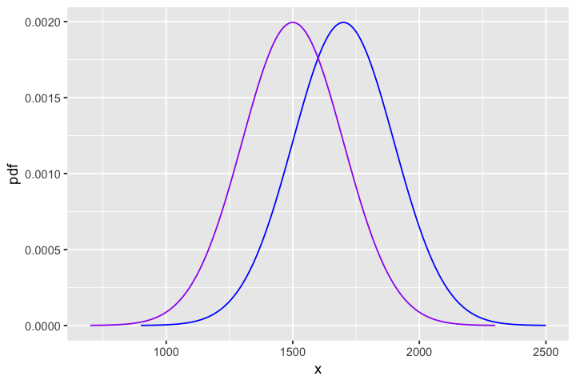

```r
player_avg <- 1500
player_sd <- 200

player1_rating <- player_avg + player_sd  # One std dev above average
player2_rating <- player_avg  # Average

player1_pdf <- normal_pdf_curve(player1_rating, player_sd, 1000)
player2_pdf <- normal_pdf_curve(player2_rating, player_sd, 1000)

ggplot() +
    geom_line(data = player1_pdf, mapping = aes(x, pdf), color = "blue") +
    geom_line(data = player2_pdf, mapping = aes(x, pdf), color = "purple")
```

## This means we can make probabilistic forecasts

```
P(Player 1 wins) = P(X > 0) = 0.760249938906523
```

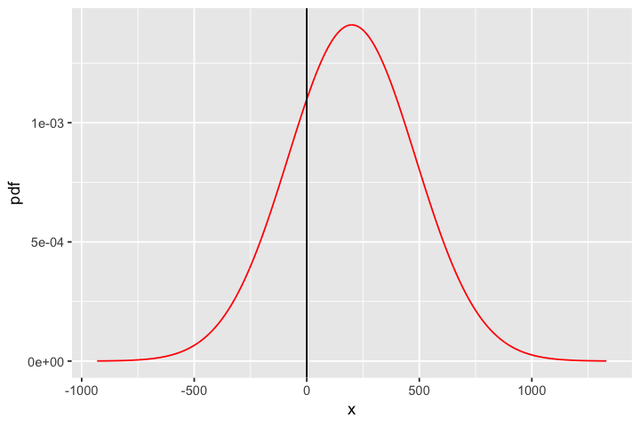

```r
delta_ratings <- player1_rating - player2_rating
combined_player_sd <- sqrt(2 * player_sd ^ 2)

combined_player_pdf <- normal_pdf_curve(delta_ratings, combined_player_sd, 1000)

combined_player_pdf %>%
    ggplot(aes(x, pdf)) +
        geom_line(colour = "red") +
        geom_vline(xintercept = 0, color = "black")

cat(str_c("P(Player 1 wins) = P(X > 0) = ", pnorm(0, delta_ratings, combined_player_sd, lower.tail = FALSE)))
```

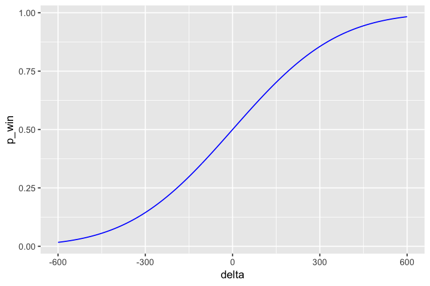

```r
player_cdf <-
    tibble(
        delta = seq(-600, 600, by = 5),
        p_win = pnorm(0, delta, combined_player_sd, lower.tail = FALSE)
    )

player_cdf %>% ggplot(aes(delta, p_win)) + geom_line(color = "blue")
```

## If the rating scale and the uncertainty (standard deviation) in performance are arbitrary, then what matters is *the ratings you give to players*

## So how do you rate players?

### The answer is *iteratively*: Keep updating based on new information

- Adjust a player's rating after **each game**, either up or down
- Adjustment is based on their performance relative to expectations
- **Expectation** is equal to the probabilty that a player will win

$$R_A'=R_A+K(S_A-E_A)$$

where

- $R_A'=$ new rating for Player A
- $R_A=$ old rating for Player A
- $K=$ adjustment coefficient
- $S_A=$ score, being 1 if Player A wins, 0 if they lose, 0.5 if they draw
- $E_A=$ expectation, the probability of Player A winning

Note that when Player A vs Player B:

$$S_B=1-S_A$$

and

$$E_B=1-E_A$$

which means that

$$R_B'=R_B+K(S_B-E_B)=R_B-K(S_A-E_A)$$

**In effect, points are transferred from the player that underperformed expectations to the player that overperformed expectations. The amount transferred is proportional to the difference between the actual result and the expected result:**

$$K(S_A-E_A)$$

### The Elo rating algorithm is continually tuning itself based on the last result

*Run through an example, use $K=20$*

## The big question is then ... What is the correct value of $K$?

- A big value of $K$ means ratings change rapidly, and more closely reflect recent **form**
- A small value of $K$ means ratings change slowly, and more closely align with **talent**

## Tuning $K$ is **key** to making Elo's rating system work

# From Grandmasters to Grand Finals

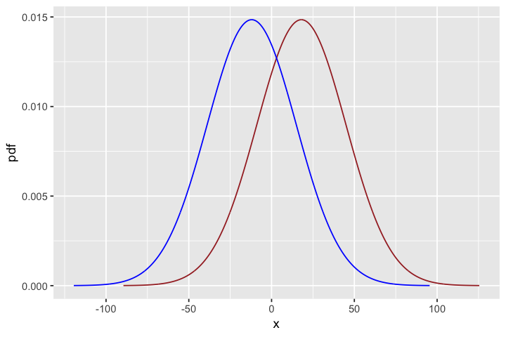

```r
hawks_rating <- +18
cats_rating <- -12
team_sd <- 38 / sqrt(2)

hawks_pdf <- normal_pdf_curve(hawks_rating, team_sd, 1000)
cats_pdf <- normal_pdf_curve(cats_rating, team_sd, 1000)

ggplot() +
    geom_line(hawks_pdf, mapping = aes(x, pdf), color = "brown") +
    geom_line(cats_pdf, mapping = aes(x, pdf), color = "blue")
```

```
P(Hawks win) = P(Margin > 0) = 0.785082397688728
```

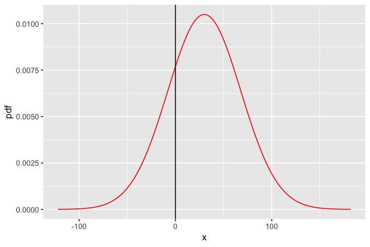

```r
margin_expected <- hawks_rating - cats_rating
margin_sd <- 38

margin_pdf <- normal_pdf_curve(margin_expected, margin_sd, 1000)

margin_pdf %>%
    ggplot(aes(x, pdf)) +
        geom_line(color = "red") +
        geom_vline(xintercept = 0, color = "black")

cat(str_c("P(Hawks win) = P(Margin > 0) = ", pnorm(0, margin_expected, margin_sd, lower.tail = FALSE)))
```

```
EA = P(Hawks win) = P(X > 0) = 0.785082397688728
SA = P(X > 0 with margin = 50) = 0.905877643358842
SA - EA = 0.120795245670114
```

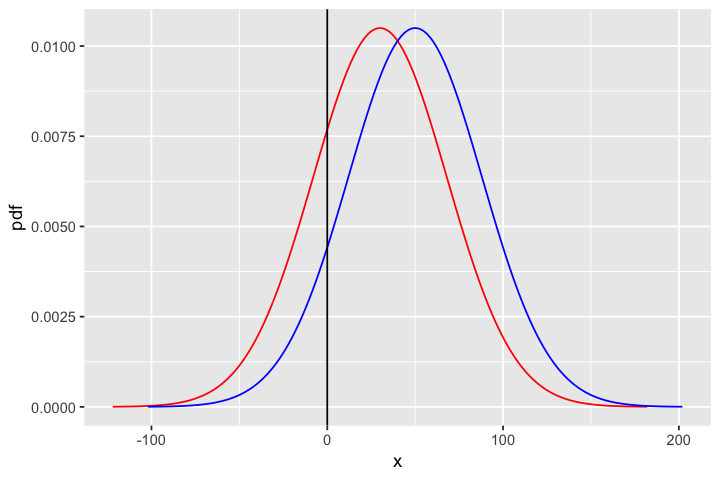

```r
margin_actual <- 50

margin_actual_pdf <- normal_pdf_curve(margin_actual, margin_sd, 1000)

margin_pdf %>%
    ggplot() +
        geom_line(margin_pdf, mapping = aes(x, pdf), color = "red") +
        geom_line(margin_actual_pdf, mapping = aes(x, pdf), color = "blue") +
        geom_vline(xintercept = 0, color = "black")

EA <- pnorm(0, margin_expected, margin_sd, lower.tail = FALSE)
SA <- pnorm(0, margin_actual, margin_sd, lower.tail = FALSE)

cat(str_c("EA = P(Hawks win) = P(X > 0) = ", EA, "\n"))
cat(str_c("SA = P(X > 0 with margin = ", margin_actual, ") = ", SA, "\n"))
cat(str_c("SA - EA = ", SA - EA, "\n"))
```

## Our scale and the uncertainty (standard deviation) are no longer arbitrary--they are linked to the predicted margin and the uncertainty in the margin

But it's circular:

- Need to know $\sigma$ to predict the margin
- Need to know the predicted margin to calculate $\sigma$

## That's the basics of a Elo rating system for AFL, but we can do more

### Regression to the mean between seasons

- Biggest unknowns tend to be at the start of a season
- All teams are **regressed to the mean** before the start of a new season
- Regression amount is controlled by the distance from the mean rating, i.e. $0$, and parameter $\alpha$

$$R_A' = R_A - \alpha(R_A-0)=(1-\alpha)R_A$$

### Ground ratings for each team

- For each team on each ground
- Iterative adjustment of team performance **on that ground**

Update after each game by amount:

$$G(S_A-E_A)$$

### It's hard to play on the road because Australia is *big*

$$T=C_1d^{C_2}$$

where

- $T=$ travel penalty
- $d=$ distance traveled
- $C_1=$ travel penalty coefficient, with $C_1\geq0$
- $C_2=$ travel penalty exponent, with $0{\leq}C_2{\leq}1$

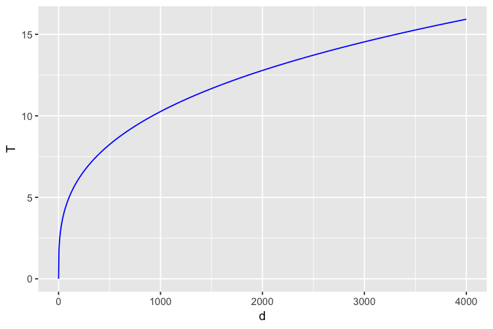

```r
c1 <- 1.1485622
c2 <- 0.3170362

travel_penalty <- travel_curve(c1, c2, 1000)

travel_penalty %>% ggplot(aes(d, T)) + geom_line(color = "blue")
```

## It becomes an optimisation problem

Need to tune the values of **seven** parameters:

- $\sigma$ to match the observed uncertainty in predicting margins
- $K=$ the coefficient for updating ratings
- $\alpha=$ the regression fraction between seasons
- $G=$ the coefficient for ground rating updates
- $C_1$ and $C_2$, the travel penalty parameters
- $R_{expn,0}=$ the initial rating for expansion teams

with the goal of making the probabilities and margins accurate, and the margin as precise as possible

# Evaluating performance

## Tune on historical data 2007-2017, check against 2018

```r
season_2018 <-
    season_2018_elo_data %>%
        select(
            team.home,
            team.away,
            delta.rating.home,
            margin.act.home,
            margin.error.home,
            result.exp.home,
            outcome.home,
            result.exp.away,
            outcome.away,
            brier.game
        ) %>%
        rename(
            home = team.home,
            away = team.away,
            margin_expected = delta.rating.home,
            margin_actual = margin.act.home,
            margin_error = margin.error.home,
            p_home_win = result.exp.home,
            outcome_home = outcome.home,
            p_away_win = result.exp.away,
            outcome_away = outcome.away,
            brier = brier.game,
        )

season_2018
```

| home | away | margin_expected | margin_actual | margin_error | p_home_win | outcome_home | p_away_win | outcome_away | brier |
| --- | --- | --- | --- | --- | --- | --- | --- | --- | --- |
| richmond | carlton | 28.5378492 | 26 | -2.5378492 | 0.7732524 | 1 | 0.2267476 | 0 | 0.05141446 |
| essendon | adelaide | -12.9956223 | 12 | 24.9956223 | 0.3664183 | 1 | 0.6335817 | 0 | 0.40142580 |
| st.kilda | brisbane.lions | 30.3370632 | 25 | -5.3370632 | 0.7872340 | 1 | 0.2127660 | 0 | 0.04526936 |
| port.adelaide | fremantle | 33.1385514 | 50 | 16.8614486 | 0.8079719 | 1 | 0.1920281 | 0 | 0.03687478 |
| hawthorn | collingwood | 2.4072774 | 34 | 31.5927226 | 0.5252090 | 1 | 0.4747910 | 0 | 0.22542649 |
| gold.coast | north.melbourne | -12.4318311 | 16 | 28.4318311 | 0.3720058 | 1 | 0.6279942 | 0 | 0.39437676 |
| greater.western.sydney | western.bulldogs | 10.6505853 | 82 | 71.3494147 | 0.6101684 | 1 | 0.3898316 | 0 | 0.15196870 |
| melbourne | geelong | -6.7511114 | -3 | 3.7511114 | 0.4296243 | 0 | 0.5703757 | 1 | 0.18457703 |
| west.coast.eagles | sydney | 0.4658994 | -29 | -29.4658994 | 0.5048820 | 0 | 0.4951180 | 1 | 0.25490586 |
| adelaide | richmond | 5.0979559 | 36 | 30.9020441 | 0.5532621 | 1 | 0.4467379 | 0 | 0.19957471 |
| north.melbourne | st.kilda | -13.2614634 | 52 | 65.2614634 | 0.3637933 | 1 | 0.6362067 | 0 | 0.40475891 |
| carlton | gold.coast | 16.3183692 | -34 | -50.3183692 | 0.6659048 | 0 | 0.3340952 | 1 | 0.44342925 |
| collingwood | greater.western.sydney | -6.1749779 | -16 | -9.8250221 | 0.4355751 | 0 | 0.5644249 | 1 | 0.18972571 |
| brisbane.lions | melbourne | -9.3911129 | -26 | -16.6088871 | 0.4025797 | 0 | 0.5974203 | 1 | 0.16207042 |
| fremantle | essendon | -1.1133254 | 16 | 17.1133254 | 0.4883352 | 1 | 0.5116648 | 0 | 0.26180092 |
| western.bulldogs | west.coast.eagles | 4.1759175 | -51 | -55.1759175 | 0.5436718 | 0 | 0.4563282 | 1 | 0.29557898 |
| sydney | port.adelaide | 22.3862717 | -23 | -45.3862717 | 0.7217399 | 0 | 0.2782601 | 1 | 0.52090847 |
| geelong | hawthorn | 2.4359118 | -1 | -3.4359118 | 0.5255085 | 0 | 0.4744915 | 1 | 0.27615914 |
| carlton | collingwood | -9.1399309 | -24 | -14.8600691 | 0.4051350 | 0 | 0.5948650 | 1 | 0.16413439 |
| port.adelaide | brisbane.lions | 43.5887244 | 5 | -38.5887244 | 0.8738831 | 1 | 0.1261169 | 0 | 0.01590546 |
| melbourne | north.melbourne | 10.9715030 | 37 | 26.0284970 | 0.6133983 | 1 | 0.3866017 | 0 | 0.14946084 |
| gold.coast | fremantle | -18.8819754 | -28 | -9.1180246 | 0.3099574 | 0 | 0.6900426 | 1 | 0.09607361 |
| st.kilda | adelaide | -14.6028203 | -49 | -34.3971797 | 0.3506483 | 0 | 0.6493517 | 1 | 0.12295421 |
| sydney | greater.western.sydney | 1.9060509 | 16 | 14.0939491 | 0.5199651 | 1 | 0.4800349 | 0 | 0.23043348 |
| richmond | hawthorn | 11.4348664 | 13 | 1.5651336 | 0.6180481 | 1 | 0.3819519 | 0 | 0.14588722 |
| western.bulldogs | essendon | -6.8575986 | 21 | 27.8575986 | 0.4285261 | 1 | 0.5714739 | 0 | 0.32658243 |
| west.coast.eagles | geelong | 14.3345408 | 15 | 0.6654592 | 0.6467363 | 1 | 0.3532637 | 0 | 0.12479524 |
| adelaide | collingwood | 27.9597001 | -48 | -75.9597001 | 0.7686520 | 0 | 0.2313480 | 1 | 0.59082587 |
| greater.western.sydney | fremantle | 32.8172628 | 31 | -1.8172628 | 0.8056584 | 1 | 0.1943416 | 0 | 0.03776866 |
| richmond | brisbane.lions | 44.4613509 | 93 | 48.5386491 | 0.8785688 | 1 | 0.1214312 | 0 | 0.01474554 |
| ⋮ | ⋮ | ⋮ | ⋮ | ⋮ | ⋮ | ⋮ | ⋮ | ⋮ | ⋮ |
| north.melbourne | western.bulldogs | 14.6998201 | -7 | -21.69982006 | 0.6502956 | 0 | 0.34970437 | 1 | 0.42288441 |
| melbourne | sydney | 19.1072154 | -9 | -28.10721537 | 0.6921266 | 0 | 0.30787338 | 1 | 0.47903925 |
| fremantle | carlton | 20.0694775 | 29 | 8.93052254 | 0.7009598 | 1 | 0.29904020 | 0 | 0.08942504 |
| richmond | essendon | 13.9182312 | 8 | -5.91823120 | 0.6426640 | 1 | 0.35733596 | 0 | 0.12768899 |
| collingwood | port.adelaide | 10.1277495 | 51 | 40.87225045 | 0.6048899 | 1 | 0.39511013 | 0 | 0.15611202 |
| geelong | fremantle | 47.8030068 | 133 | 85.19699320 | 0.8953762 | 1 | 0.10462383 | 0 | 0.01094615 |
| greater.western.sydney | sydney | 1.5872560 | -20 | -21.58725602 | 0.5166280 | 0 | 0.48337200 | 1 | 0.26690449 |
| st.kilda | hawthorn | -23.5576372 | -4 | 19.55763724 | 0.2680286 | 0 | 0.73197137 | 1 | 0.07183935 |
| gold.coast | brisbane.lions | -23.3988471 | -4 | 19.39884709 | 0.2694044 | 0 | 0.73059557 | 1 | 0.07257875 |
| carlton | western.bulldogs | -21.1444662 | -17 | 4.14446624 | 0.2893107 | 0 | 0.71068932 | 1 | 0.08370067 |
| west.coast.eagles | melbourne | 15.7298524 | -17 | -32.72985240 | 0.6602606 | 0 | 0.33973939 | 1 | 0.43594407 |
| adelaide | north.melbourne | 12.0963999 | 9 | -3.09639988 | 0.6246570 | 1 | 0.37534300 | 0 | 0.14088237 |
| port.adelaide | essendon | 0.1297115 | -22 | -22.12971154 | 0.5013592 | 0 | 0.49864076 | 1 | 0.25136109 |
| geelong | gold.coast | 56.2639880 | 102 | 45.73601196 | 0.9302801 | 1 | 0.06971986 | 0 | 0.00486086 |
| richmond | western.bulldogs | 36.2144789 | 3 | -33.21447889 | 0.8292593 | 1 | 0.17074073 | 0 | 0.02915240 |
| fremantle | collingwood | -20.9215361 | -9 | 11.92153614 | 0.2913161 | 0 | 0.70868389 | 1 | 0.08486508 |
| carlton | adelaide | -27.6231180 | -104 | -76.37688202 | 0.2340501 | 0 | 0.76594993 | 1 | 0.05477943 |
| sydney | hawthorn | 7.0738664 | -9 | -16.07386644 | 0.5737026 | 0 | 0.42629745 | 1 | 0.32913462 |
| brisbane.lions | west.coast.eagles | -5.8640117 | -26 | -20.13598832 | 0.4387933 | 0 | 0.56120673 | 1 | 0.19253953 |
| melbourne | greater.western.sydney | 15.6011867 | 45 | 29.39881327 | 0.6590218 | 1 | 0.34097823 | 0 | 0.11626615 |
| st.kilda | north.melbourne | -12.7902202 | -23 | -10.20977985 | 0.3684507 | 0 | 0.63154928 | 1 | 0.13575593 |
| richmond | hawthorn | 10.6436552 | 31 | 20.35634477 | 0.6100985 | 1 | 0.38990147 | 0 | 0.15202316 |
| melbourne | geelong | 5.4557246 | 29 | 23.54427536 | 0.5569753 | 1 | 0.44302466 | 0 | 0.19627085 |
| greater.western.sydney | sydney | 1.5311256 | 49 | 47.46887440 | 0.5160403 | 1 | 0.48395969 | 0 | 0.23421698 |
| west.coast.eagles | collingwood | 10.2098426 | 16 | 5.79015743 | 0.6057200 | 1 | 0.39428003 | 0 | 0.15545674 |
| melbourne | hawthorn | 9.9927067 | 33 | 23.00729329 | 0.6035233 | 1 | 0.39647669 | 0 | 0.15719376 |
| collingwood | greater.western.sydney | 10.0624807 | 10 | -0.06248065 | 0.6042295 | 1 | 0.39577045 | 0 | 0.15663425 |
| collingwood | richmond | -12.8542022 | 39 | 51.85420216 | 0.3678172 | 1 | 0.63218278 | 0 | 0.39965506 |
| west.coast.eagles | melbourne | 5.7142464 | 66 | 60.28575360 | 0.5596554 | 1 | 0.44034462 | 0 | 0.19390338 |
| west.coast.eagles | collingwood | -13.7075618 | 5 | 18.70756184 | 0.3594029 | 1 | 0.64059706 | 0 | 0.41036460 |

| p | outcome |
| --- | --- |
| 0.18664012 | 0 |
| 0.15074122 | 0 |
| 0.19202807 | 0 |
| 0.12611685 | 0 |
| 0.19434161 | 0 |
| 0.12143123 | 0 |
| 0.15307555 | 0 |
| 0.15489501 | 0 |
| 0.11904910 | 0 |
| 0.12054835 | 0 |
| 0.12395312 | 0 |
| 0.17472946 | 0 |
| 0.16487066 | 0 |
| 0.18615536 | 0 |
| 0.12573837 | 0 |
| 0.11622242 | 0 |
| 0.19351691 | 0 |
| 0.17628159 | 0 |
| 0.19891744 | 0 |
| 0.15592136 | 0 |
| 0.09879809 | 1 |
| 0.14889872 | 0 |
| 0.08720466 | 0 |
| 0.10462383 | 0 |
| 0.06971986 | 0 |
| 0.17074073 | 0 |

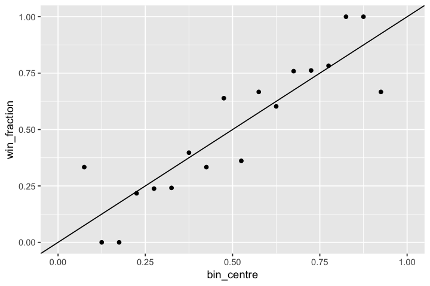

```r
# Calibration curve
season_2018_home <- season_2018 %>% select(p_home_win, outcome_home) %>% rename(p = p_home_win, outcome = outcome_home)
season_2018_away <- season_2018 %>% select(p_away_win, outcome_away) %>% rename(p = p_away_win, outcome = outcome_away)
season_2018_pred_act <- union(season_2018_home, season_2018_away)

n_preds <- season_2018_pred_act %>% nrow()

season_2018_pred_act %>%
    group_by(cut(p, breaks = seq(0, 1, 0.05))) %>%
    summarize(n(), sum(outcome)) %>%
    rename(bin = `cut(p, breaks = seq(0, 1, 0.05))`, n_games = `n()`, n_wins = `sum(outcome)`) %>%
    mutate(bin_centre = seq(0.075, 0.925, 0.05), win_fraction = n_wins / n_games) %>%
    ggplot(aes(bin_centre, win_fraction)) +
        geom_point() +
        geom_abline(slope = 1, intercept = 0) +
        scale_x_continuous(limits = c(0, 1))

season_2018_pred_act %>% filter(p < 0.2)
```

```r
# Measures of performance
cat(str_c("Margin mean absolute error = ", mean(abs(season_2018$margin_error)), " points\n"))
cat(str_c("Margin error std dev = ", sd(season_2018$margin_error), " points\n"))
cat(str_c("Brier score = ", mean(season_2018$brier), "\n"))

# Tipping score
n_correct_tips <-
    season_2018 %>%
        filter((p_home_win > 0.5 & outcome_home == 1) | (p_away_win > 0.5 & outcome_away == 1)) %>%
        count() %>%
        pull(n)
n_games <- season_2018 %>% count()
cat(str_c("Tipping score = ", n_correct_tips, " out of ", n_games, " (including finals) = ", n_correct_tips/n_games*100, " per cent\n"))
```

```
Margin mean absolute error = 27.008992845873 points
Margin error std dev = 34.3283764992442 points
Brier score = 0.196950602371446
Tipping score = 139 out of 207 (including finals) = 67.1497584541063 per cent
```

# Predicting the future

## Current team ratings, as of right now

```r
team_data %>%
  filter(yes.active) %>%
  arrange(desc(rating)) %>%
  select(team, rating)
```

| team | rating |
| --- | --- |
| geelong | 16.3012506 |
| collingwood | 13.0197078 |
| greater.western.sydney | 12.7913423 |
| west.coast.eagles | 9.1472283 |
| richmond | 7.3669073 |
| essendon | 3.5678253 |
| port.adelaide | 2.7054856 |
| adelaide | 1.1109188 |
| north.melbourne | 0.6778908 |
| hawthorn | 0.4200030 |
| brisbane.lions | -1.5765528 |
| sydney | -2.3269530 |
| melbourne | -4.3233214 |
| fremantle | -5.3613036 |
| western.bulldogs | -9.0034301 |
| st.kilda | -15.4417335 |
| carlton | -20.7297326 |
| gold.coast | -24.0241698 |

## Predictions and tips for Round 12, 2019 (starts tonight)

```r
file.show("~/lab/afl-elo/out/NEW_afl_elo_pred_2019-R12.txt")
```

```
R Information


++++++++++++++++++++++++++
PREDICTIONS for 2019-R12
++++++++++++++++++++++++++

Generated: 2019-06-06 13:27:38
Last known game: 15506. 2019-R11 (2019-06-02) West Coast 21.7.133 vs Western Bulldogs 10.12.72 at Perth Stadium

Git commit hash: 7b0156ba5e6f0a0b2482d24a1dbbd8b71d74c052
Git status:
 M afl_params.R
 M afl_test_mc_sims.R
 M test.R


+++++++++++++++++++++++++++++++++++++++++++++++++++++++++++
RICHMOND vs GEELONG CATS at M.C.G.
-----------------------------------------------------------
Team         |  Richmond            |  Geelong Cats
-----------------------------------------------------------
Win prob.    |       41.7 per cent  |       58.3 per cent
Margin       |       -8.0 points    |       +8.0 points
-----------------------------------------------------------
Tip          |  Lose: Toss-up       |  Win: Toss-up
-----------------------------------------------------------
Team rating  |        7.4           |       16.3
Travel adj.  |       -0.0           |       -0.0
Ground adj.  |       +1.1           |       +0.1
-----------------------------------------------------------
Rating tot.  |        8.5           |       16.4
-----------------------------------------------------------
Delta        |       -8.0           |       +8.0
-----------------------------------------------------------
Bookie
  Back       |  >     2.40          |  >     1.72
Exchange (commission of 5.00 per cent)
  Back       |  >     2.47          |  >     1.75
  Lay        |  <     2.33          |  <     1.68
```

[output cut: 116 more lines]

```
-----------------------------------------------------------
Team rating  |       13.0           |       -4.3
Travel adj.  |       -0.0           |       -0.0
Ground adj.  |       -3.3           |       +0.8
-----------------------------------------------------------
Rating tot.  |        9.7           |       -3.6
-----------------------------------------------------------
Delta        |      +13.2           |      -13.2
-----------------------------------------------------------
Bookie
  Back       |  >     1.57          |  >     2.75
Exchange (commission of 5.00 per cent)
  Back       |  >     1.60          |  >     2.84
  Lay        |  <     1.54          |  <     2.66
+++++++++++++++++++++++++++++++++++++++++++++++++++++++++++
```

## Predicting the rest of the 2019 regular season

### Current ladder, as of end Round 11

```r
ladder_data %>%
    select(ladder.posn, team, won, lost, drawn, prem.pts, percentage)
```

| ladder.posn | team | won | lost | drawn | prem.pts | percentage |
| --- | --- | --- | --- | --- | --- | --- |
| 1 | geelong | 10 | 1 | 0 | 40 | 144.87350 |
| 2 | greater.western.sydney | 8 | 3 | 0 | 32 | 138.99614 |
| 3 | collingwood | 8 | 3 | 0 | 32 | 124.35105 |
| 4 | west.coast.eagles | 8 | 3 | 0 | 32 | 108.83777 |
| 5 | brisbane.lions | 7 | 4 | 0 | 28 | 104.91453 |
| 6 | richmond | 7 | 4 | 0 | 28 | 101.34378 |
| 7 | port.adelaide | 6 | 5 | 0 | 24 | 110.93023 |
| 8 | adelaide | 6 | 5 | 0 | 24 | 110.73658 |
| 9 | fremantle | 6 | 5 | 0 | 24 | 109.03226 |
| 10 | essendon | 5 | 6 | 0 | 20 | 102.93399 |
| 11 | hawthorn | 5 | 6 | 0 | 20 | 101.17233 |
| 12 | st.kilda | 5 | 6 | 0 | 20 | 85.56375 |
| 13 | north.melbourne | 4 | 7 | 0 | 16 | 91.03726 |
| 14 | western.bulldogs | 4 | 7 | 0 | 16 | 88.71129 |
| 15 | sydney | 3 | 8 | 0 | 12 | 84.45596 |
| 16 | melbourne | 3 | 8 | 0 | 12 | 77.78884 |
| 17 | gold.coast | 3 | 8 | 0 | 12 | 69.84127 |
| 18 | carlton | 1 | 10 | 0 | 4 | 74.32024 |

### One simulation of the rest of the season

```r
ladder_mc_sims %>%
    filter(sim.itn == 1) %>%
    select(ladder.posn, team, won, lost, drawn, prem.pts, percentage) %>%
    arrange(ladder.posn)
```

| ladder.posn | team | won | lost | drawn | prem.pts | percentage |
| --- | --- | --- | --- | --- | --- | --- |
| 1 | geelong | 18 | 4 | 0 | 72 | 138.29540 |
| 2 | richmond | 17 | 5 | 0 | 68 | 124.93635 |
| 3 | greater.western.sydney | 16 | 6 | 0 | 64 | 132.50009 |
| 4 | adelaide | 14 | 8 | 0 | 56 | 116.55622 |
| 5 | fremantle | 13 | 9 | 0 | 52 | 109.63979 |
| 6 | brisbane.lions | 12 | 10 | 0 | 48 | 103.58753 |
| 7 | port.adelaide | 11 | 11 | 0 | 44 | 104.43543 |
| 8 | essendon | 11 | 11 | 0 | 44 | 104.26682 |
| 9 | collingwood | 11 | 11 | 0 | 44 | 100.12607 |
| 10 | west.coast.eagles | 11 | 11 | 0 | 44 | 97.78350 |
| 11 | western.bulldogs | 11 | 11 | 0 | 44 | 95.71579 |
| 12 | hawthorn | 9 | 13 | 0 | 36 | 96.12716 |
| 13 | st.kilda | 9 | 13 | 0 | 36 | 89.11004 |
| 14 | north.melbourne | 9 | 13 | 0 | 36 | 85.64914 |
| 15 | sydney | 7 | 15 | 0 | 28 | 89.75283 |
| 16 | melbourne | 7 | 15 | 0 | 28 | 87.69126 |
| 17 | gold.coast | 7 | 15 | 0 | 28 | 72.21530 |
| 18 | carlton | 5 | 17 | 0 | 20 | 77.85206 |

### 20,000 Monte Carlo simulations later

```r
team_of_interest <- "hawthorn"
```

[output not shown]

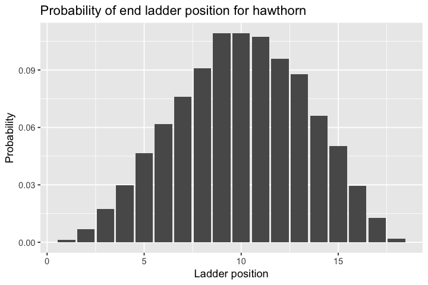

```r
n_itns <- 20000

ladder_posn_prob <-
  ladder_mc_sims %>%
    filter(team == team_of_interest) %>%
    group_by(ladder.posn) %>%
    count() %>%
    mutate(p = n/n_itns)

ladder_posn_prob %>%
    ggplot(aes(ladder.posn, p)) +
      geom_col() +
      ggtitle(
        paste0(
          "Probability of end ladder position for ",
          team_of_interest
        )
      ) +
      xlab("Ladder position") +
      ylab("Probability")

tibble(
    event = c(
        "Top of ladder (Minor premiers)",
        "Top 4 (2nd chance in finals)",
        "Top 8 (Play in finals)",
        "Bottom of ladder (Wooden spoon)"
    ),
    p = c(
        ladder_posn_prob %>% filter(ladder.posn == 1) %>% pull(p),
        ladder_posn_prob %>% filter(ladder.posn <= 4) %>% pull(p) %>% sum(),
        ladder_posn_prob %>% filter(ladder.posn <= 8) %>% pull(p) %>% sum(),
        ladder_posn_prob %>% filter(ladder.posn == 16) %>% pull(p)
    )
)
```

## I wanna know who'll win the flag

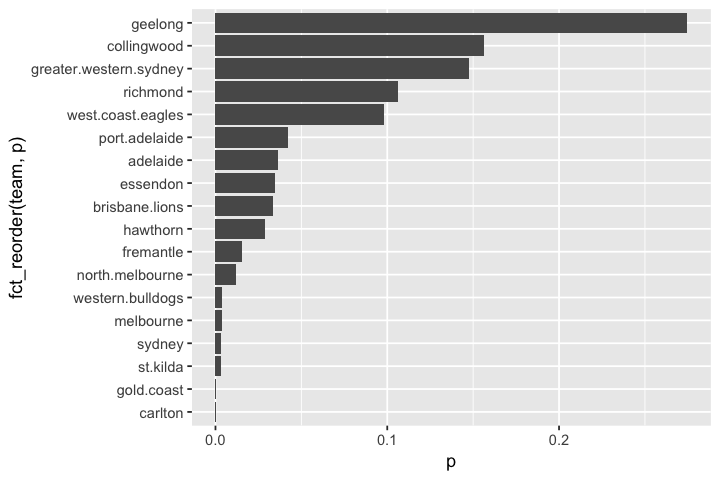

```r
finals_mc_sims %>%
    filter(rnd == "GF") %>%
    count(winner) %>%
    mutate(p = n / n_itns) %>%
    rename(team = winner) %>%
    arrange(desc(p)) %>%
    select(-n) %>%
    ggplot(aes(fct_reorder(team, p), p)) +
        geom_col() +
        coord_flip()
```

# Useful resources

### Squiggle

https://squiggle.com.au/

### AFL Tables

https://afltables.com/afl/afl_index.html

### fitzRoy

https://github.com/jimmyday12/fitzRoy